# Birth Weight Analysis Code

Nick Hass

1/19/2022

## Birth Weight Data

```r
bw <- read.csv('BirthWeights.txt', sep = " ")
summary(bw)
```

```
##   BirthWeight        Mage            Gage          Race
##  Min.   :1625   Min.   :13.00   Min.   :34.0   Length:832
##  1st Qu.:2781   1st Qu.:27.00   1st Qu.:38.0   Class :character
##  Median :3094   Median :31.00   Median :39.0   Mode  :character
##  Mean   :3086   Mean   :30.75   Mean   :39.5
##  3rd Qu.:3402   3rd Qu.:35.00   3rd Qu.:41.0
##  Max.   :4653   Max.   :46.00   Max.   :45.0
##      Gen
##  Length:832
##  Class :character
##  Mode  :character
##
##
##
```

```r
head(bw)
```

```
##   BirthWeight Mage Gage  Race    Gen
## 1     3026.97   23   39 white   Male
## 2     3233.11   36   39 white Female
## 3     2644.39   36   38  hisp   Male
## 4     4000.45   23   42 white   Male
## 5     3281.49   28   38 white Female
## 6     2748.88   41   41  hisp   Male
```

```r
dplyr::glimpse(bw)
```

```
## Rows: 832
## Columns: 5
## $ BirthWeight <dbl> 3026.97, 3233.11, 2644.39, 4000.45, 3281.49, 2748.88, 3030…
## $ Mage        <int> 23, 36, 36, 23, 28, 41, 37, 34, 34, 33, 32, 39, 24, 26, 28…
## $ Gage        <int> 39, 39, 38, 42, 38, 41, 39, 37, 39, 40, 41, 37, 36, 35, 38…
## $ Race        <chr> "white", "white", "hisp", "white", "white", "hisp", "hisp"…
## $ Gen         <chr> "Male", "Female", "Male", "Male", "Female", "Male", "Femal…
```

## Exploratory Data Analysis

1. Scatterplot of BirthWeight by Mage
2. Side-by-side boxplots of BirthWeight for each category in Race
3. A scatterplot of BirthWeight by Gage where the dots are colored according to Gen
4. The correlation between BirthWeight and Mage.
5. A pairs plot of all the variables in the BirthWeight dataset.

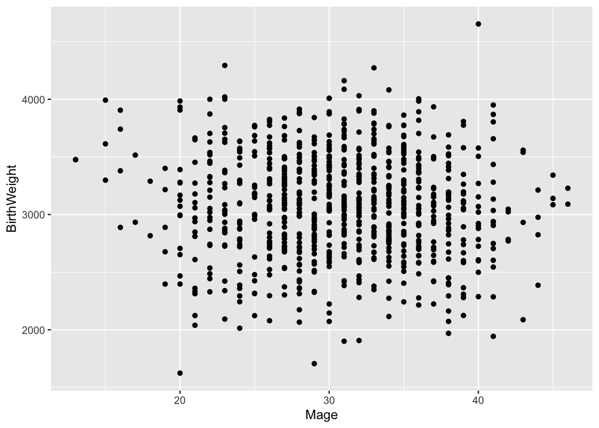

```r
#1.
ggplot(bw, aes(x = Mage, y = BirthWeight)) +
  geom_point()
```

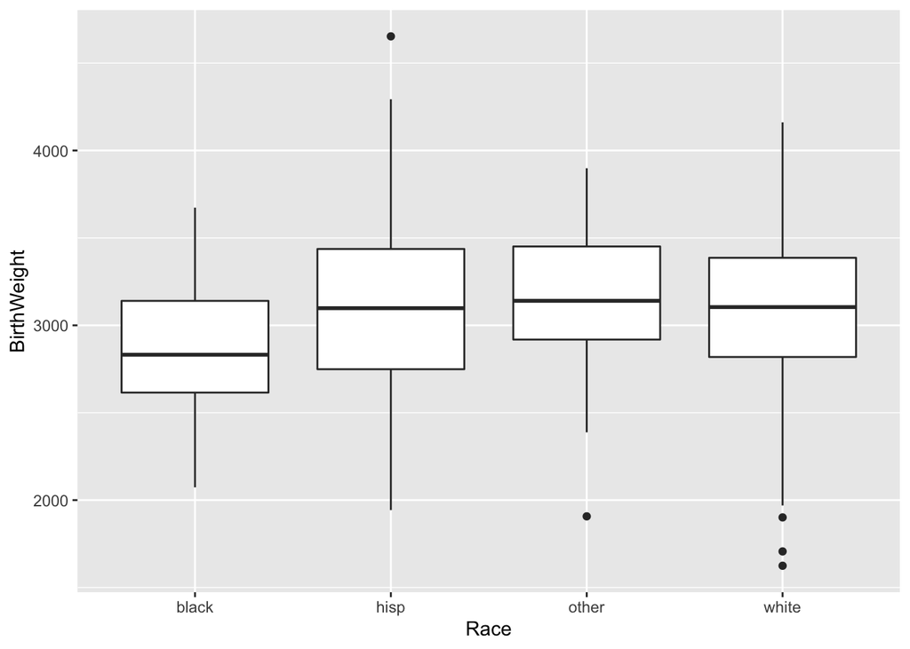

```r
#2.
ggplot(bw, aes(x = Race, y = BirthWeight)) +
  geom_boxplot()
```

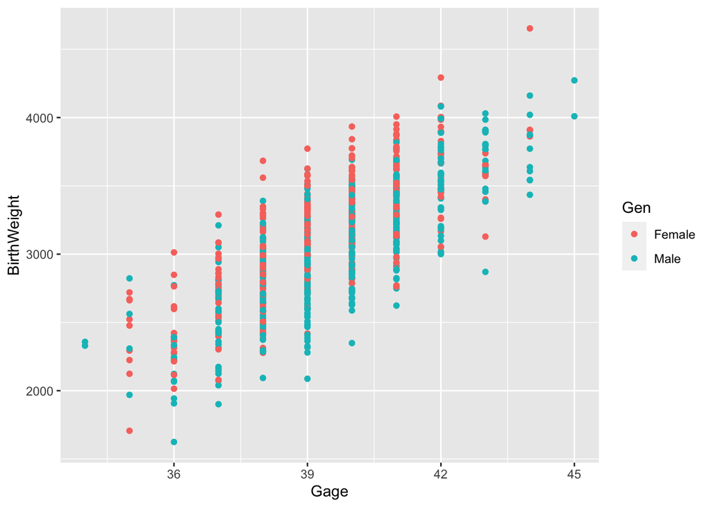

```r
#3.
ggplot(bw, aes(x = Gage, y = BirthWeight, colour = Gen)) +
  geom_point() # color by Gen +
```

```r
#4.
cor(bw["BirthWeight"], bw["Mage"])
```

```
##                   Mage
## BirthWeight -0.0537451
```

```r
#5.
library(GGally)
```

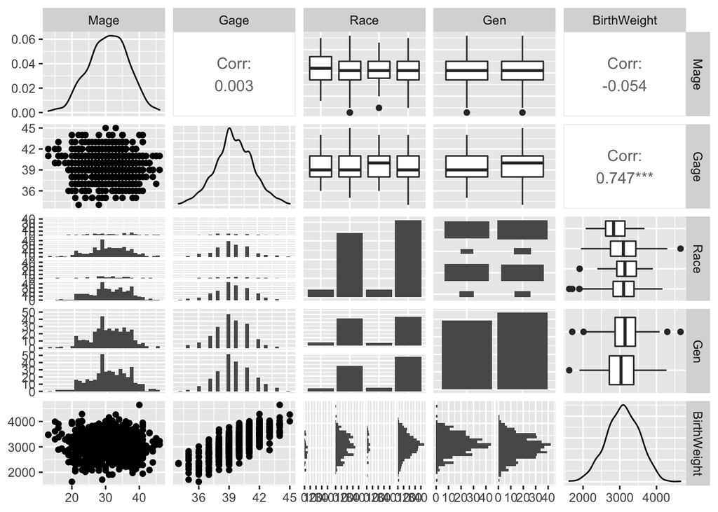

```r
response <- bw$BirthWeight
bw <- bw[-1]
bw$BirthWeight <- response
ggpairs(bw)
```

## Fitting a Linear Model

#### 1. Without the use of lm() calculate β̂ and s2. Verify your answer using lm().

```r
#1.
X <- model.matrix(BirthWeight~., data = bw)
P <- 6
n <- dim(bw)[1]

beta_hat <- solve(t(X)%*%X) %*% t(X) %*% bw$BirthWeight

resid_variance <- t(bw$BirthWeight - X %*% beta_hat) %*% (bw$BirthWeight - X %*% beta_hat) / (n-P-1)
bw.lm <- lm(BirthWeight ~ ., data=bw)

print(lm(BirthWeight ~ ., data=bw))
```

```
##
## Call:
## lm(formula = BirthWeight ~ ., data = bw)
##
## Coefficients:
## (Intercept)         Mage         Gage     Racehisp    Raceother    Racewhite
##   -4120.542       -3.794      182.742      198.748      241.583      204.888
##     GenMale
##    -169.349
```

```r
print(beta_hat)
```

```
##                     [,1]
## (Intercept) -4120.542409
## Mage           -3.793751
## Gage          182.742497
## Racehisp      198.747954
## Raceother     241.582827
## Racewhite     204.888197
## GenMale      -169.348562
```

```r
print(resid_variance)
```

```
##          [,1]
## [1,] 79277.09
```

```r
sigma(bw.lm)^2
```

```
## [1] 79277.09
```

My numbers are the same.

#### 2. Without the use of lm() calculate the fitted values Xβ̂ . Verify your calculations by pulling off the fitted values from an lm() object.

```r
fitted_values <- X%*%beta_hat
# fitted(bw.lm) # don't want to print out all the rows

head(round(fitted_values, 5) == round(fitted(bw.lm), 5))
```

```
##   [,1]
## 1 TRUE
## 2 TRUE
## 3 TRUE
## 4 TRUE
## 5 TRUE
## 6 TRUE
```

```r
tail(round(fitted_values, 5) == round(fitted(bw.lm), 5))
```

```
##     [,1]
## 827 TRUE
## 828 TRUE
## 829 TRUE
## 830 TRUE
## 831 TRUE
## 832 TRUE
```

My calculated fitted values and the fitted values from the lm() object are the same.

#### 3. Without the use of lm() calculate the residuals y−Xβ̂ Verify your calculations by pulling off the residuals from an lm() object.

```r
residuals = bw$BirthWeight - (X %*% beta_hat)
# resid(bw.lm)

head(round(residuals, 5) == round(resid(bw.lm), 5))
```

```
##   [,1]
## 1 TRUE
## 2 TRUE
## 3 TRUE
## 4 TRUE
## 5 TRUE
## 6 TRUE
```

```r
tail(round(residuals, 5) == round(resid(bw.lm), 5))
```

```
##     [,1]
## 827 TRUE
## 828 TRUE
## 829 TRUE
## 830 TRUE
## 831 TRUE
## 832 TRUE
```

#### 4. Identify your model R2 from the summary() output.

```r
summary(bw.lm)$r.squared
```

```
## [1] 0.6064689
```

## Checking Assumptions

#### 1. Construct added variable plots and assess if the linearity assumption is OK for this data.

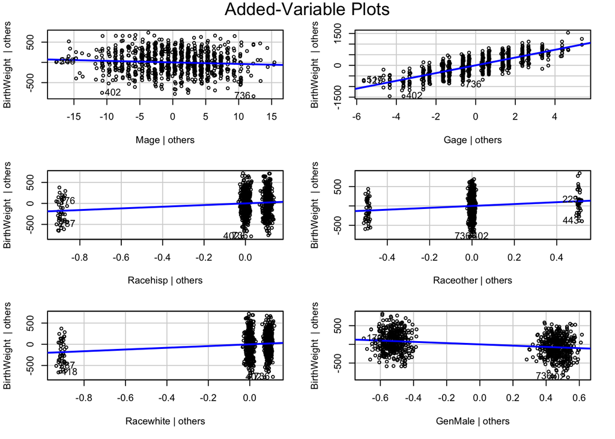

```r
car::avPlots(bw.lm)
```

Linearity assumption is ok.

#### 2. Construct a histogram of the standardized residuals and run a KS-test to see if the normality assumption is OK for this data.

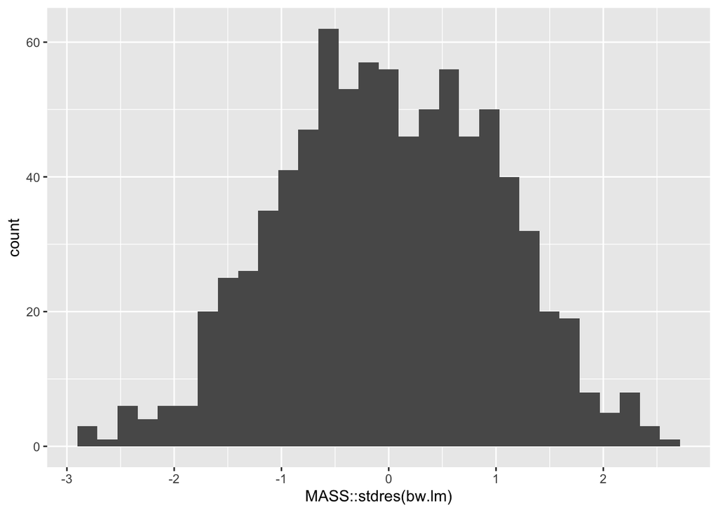

```r
standardized.residuals = MASS::stdres(bw.lm)

ggplot() +
  geom_histogram(mapping = aes(x = MASS::stdres(bw.lm) ))
```

```r
# KS Test
ks.test(standardized.residuals, "pnorm")
```

```
##
##  One-sample Kolmogorov-Smirnov test
##
## data:  standardized.residuals
## D = 0.028947, p-value = 0.4884
## alternative hypothesis: two-sided
```

Histogram of the standardized residuals looks normal. Results from the KS test indicate that the standardized residuals follow a normal distribution because of the hi p-value (failing to reject that it is not normal).

#### 3. Draw a scatterplot of the fitted values vs. standardized residuals and run a BP-test to see if the equal variance assumption is OK for this data.

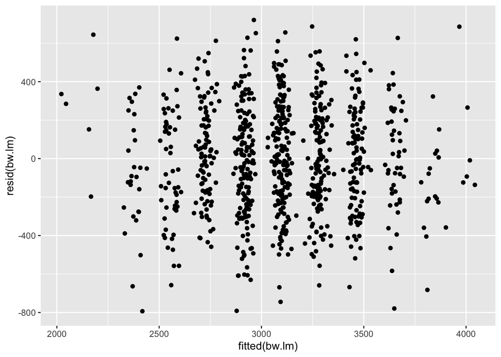

```r
ggplot() +
  geom_point(mapping = aes(x = fitted(bw.lm), y = resid(bw.lm) ))
```

```r
lmtest::bptest(bw.lm)
```

```
##
##  studentized Breusch-Pagan test
##
## data:  bw.lm
## BP = 6.8177, df = 6, p-value = 0.338
```

## Predictions

#### 1. Without using predict.lm(), calculate your point prediction of the birth weight for a baby with Mage=26, Gage=37, Race=“hisp” and Gen=“Female” using the formula ŷ new=xnewβ̂ where β̂ is the maximum likelihood estimate that you calculated above. Confirm that this is what predict.lm() is doing to get the point prediction.

```r
new.x = data.frame(Mage=26, Gage=37, Race="hisp", Gen="Female")
predict.lm(bw.lm, newdata=new.x, interval="prediction", level=0.97)
```

```
##       fit      lwr      upr
## 1 2741.04 2126.917 3355.164
```

```r
# without using predict.lm()
# Set up x matrix
x.new = matrix(c(1, 26, 37, 1, 0, 0, 0), ncol=1)
t(x.new) %*% coef(bw.lm)
```

```
##         [,1]
## [1,] 2741.04
```

They are both 2741.04.

#### 2. Using predict.lm(), get a prediction of the birth weight for a baby with Mage=26, Gage=37, Race=“hisp” and Gen=“Female” and an associated 99% prediction interval.

```r
newer.x = data.frame(Mage=26, Gage=37, Race="hisp", Gen="Female")
predict.lm(bw.lm, newdata=newer.x, interval="prediction", level=0.99)
```

```
##       fit      lwr      upr
## 1 2741.04 2011.669 3470.412
```

## Cross Validation

```r
n.cv <- 100 #Number of CV studies to run
n.test <- round(dim(bw)[1]*.8) #Number of observations in a test set
rpmse <- rep(x=NA, times=n.cv)
bias <- rep(x=NA, times=n.cv)
wid <- rep(x=NA, times=n.cv)
cvg <- rep(x=NA, times=n.cv)
for(cv in 1:n.cv) {
  ## Select test observations
  test.obs <- sample(x = 1:n, size = n.test)

  ## Split into test and training sets
  test.set <- bw[test.obs,]
  train.set <- bw[-test.obs,]

  ## Fit a lm() using the training data
  train.lm <- lm(formula = BirthWeight~., data = train.set)

  ## Generate predictions for the test set
  my.preds <- predict.lm(train.lm, newdata = test.set, interval = "prediction")

  ## Calculate bias
  bias[cv] <- mean(my.preds[,'fit'] - test.set[['BirthWeight']])

  ## Calculate RPMSE
  rpmse[cv] <- (test.set[['BirthWeight']] - my.preds[,'fit'])^2 %>% mean() %>% sqrt()

  ## Calculate Coverage
  cvg[cv] <- ((test.set[['BirthWeight']] > my.preds[,'lwr']) & (test.set[['BirthWeight']] < my.preds[,'upr'])) %>% mean()

  ## Calculate Width
  wid[cv] <- (my.preds[,'upr'] - my.preds[,'lwr']) %>% mean()

}
```

#### Adjust the above code to run 100 Monte Carlo cross validations and plot histograms (or density plots) of the bias, RPMSE, coverage and width.

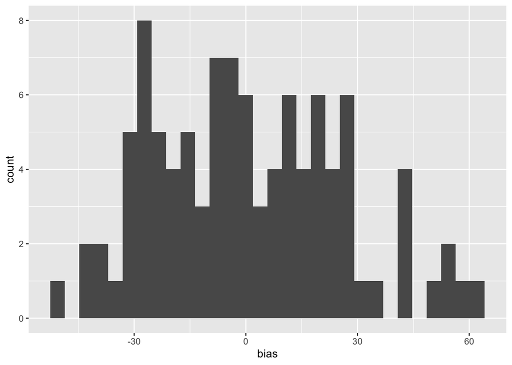

```r
ggplot() +
  geom_histogram(mapping = aes(x =  bias))
```

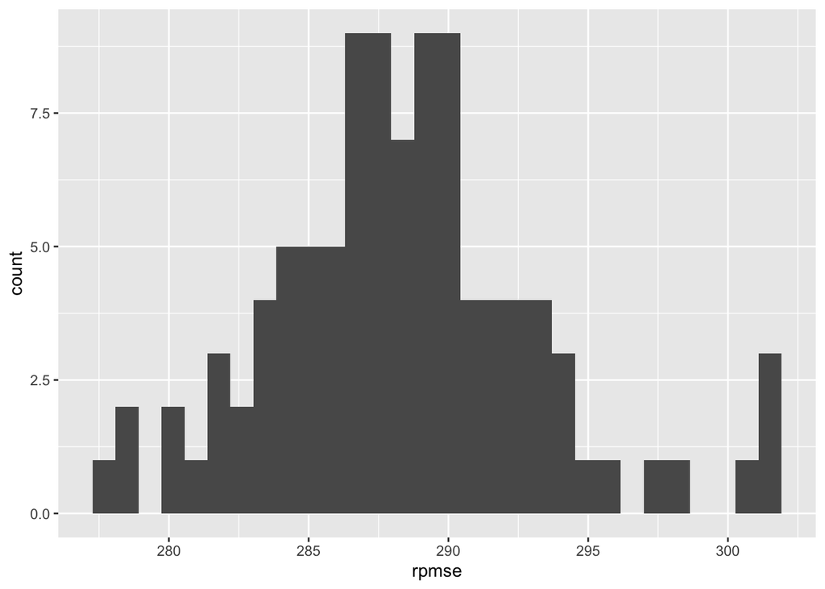

```r
ggplot() +
  geom_histogram(mapping = aes(x =  rpmse))
```

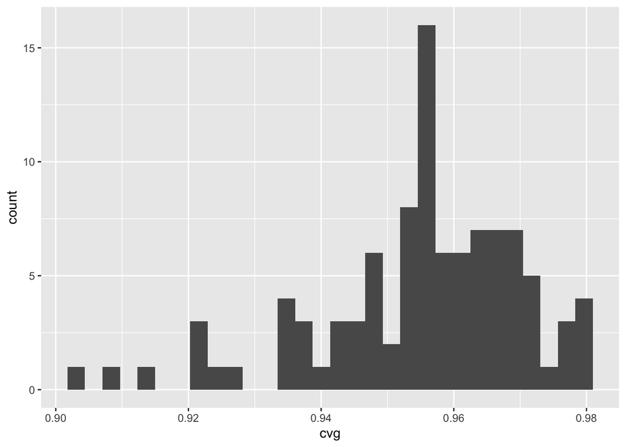

```r
ggplot() +
  geom_histogram(mapping = aes(x =  cvg))
```

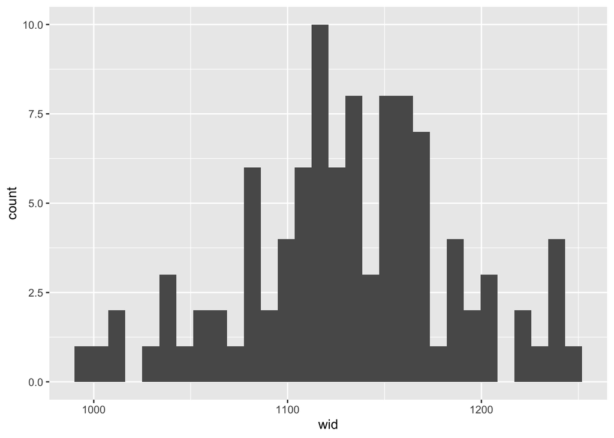

```r
ggplot() +
  geom_histogram(mapping = aes(x =  wid))
```

## Hypothesis Testing and Confidence Intervals

#### 1. Using lm() construct the t−statistic and p-value for the test H0:βMage=0.

```r
#summary(lm(BirthWeight ~ ., data = bw))
pval <- summary(lm(BirthWeight ~ ., data = bw))$coefficients[2,4] # P value
sprintf("p-value: %f", pval)
```

```
## [1] "p-value: 0.024171"
```

```r
tstat <- summary(lm(BirthWeight ~ ., data = bw))$coefficients[2,3] # T statistic
sprintf("t-value: %f", tstat)
```

```
## [1] "t-value: -2.258559"
```

T-statistic for Mage=0 is -2.259, with p-value=0.024

#### 2. Using confint() and lm(), build a 90% confidence interval for βMage.

```r
confint(lm(BirthWeight ~ ., data = bw), level = .9)
```

```
##                      5 %         95 %
## (Intercept) -4479.605600 -3761.479218
## Mage           -6.559754    -1.027749
## Gage          174.087836   191.397158
## Racehisp      121.984183   275.511725
## Raceother     138.434736   344.730917
## Racewhite     128.849185   280.927208
## GenMale      -201.750236  -136.946888
```

```r
confint(lm(BirthWeight ~ ., data = bw), level = .9)[ "Mage", ]
```

```
##       5 %      95 %
## -6.559754 -1.027749
```

#### 3. Using anova(), conduct a F test that race has no effect on birth weight (note: this answers primary research question #2).

```r
full.lm <- bw.lm
reduced.lm <- lm(BirthWeight ~ Mage + Gage + Gen, data = bw)
anova(full.lm,reduced.lm)
```

```
## Analysis of Variance Table
##
## Model 1: BirthWeight ~ Mage + Gage + Race + Gen
## Model 2: BirthWeight ~ Mage + Gage + Gen
##   Res.Df      RSS Df Sum of Sq      F   Pr(>F)
## 1    825 65403597
## 2    828 67089176 -3  -1685579 7.0873 0.000105 ***
## ---
## Signif. codes:  0 '***' 0.001 '**' 0.01 '*' 0.05 '.' 0.1 ' ' 1
```

Since the p-value is low, we reject the reduced model and conclude that (the full model is better) race has effect on birth weight.

#### 4. Using glht(), conduct a t test and 94% confidence interval for the difference in average birth weight of babies born with explanatory variables Mage=24, Gage=40, Race=“white” and Gen=“Male” and babies born with explanatory variables Mage=34, Gage=33, Race=“white” and Gen=“Male”.

```r
# Difference in birth weight
baby1 <- matrix(c(1, 24, 40, 0, 0, 1, 1), nrow=1)
baby2 <- matrix(c(1, 34, 33, 0, 0, 1, 1), nrow=1)
diff_bw <- baby2-baby1
ht <- multcomp::glht(bw.lm, linfct=diff_bw, alternative="two.sided")
summary(ht)
```

```
##
##   Simultaneous Tests for General Linear Hypotheses
##
## Fit: lm(formula = BirthWeight ~ ., data = bw)
##
## Linear Hypotheses:
##        Estimate Std. Error t value Pr(>|t|)
## 1 == 0 -1317.13      40.48  -32.54   <2e-16 ***
## ---
## Signif. codes:  0 '***' 0.001 '**' 0.01 '*' 0.05 '.' 0.1 ' ' 1
## (Adjusted p values reported -- single-step method)
```

```r
confint(ht, level=0.94)
```

```
##
##   Simultaneous Confidence Intervals
##
## Fit: lm(formula = BirthWeight ~ ., data = bw)
##
## Quantile = 1.8834
## 94% family-wise confidence level
##
##
## Linear Hypotheses:
##        Estimate   lwr        upr
## 1 == 0 -1317.1350 -1393.3746 -1240.8954
```

I am 94% confident that baby number one is 1317.135 grams heavier than baby number 2.